# Household Income and Age in relation to home values in Ramsey County, MN

Author

Iris Fokam and Katelyn McClure

Published

November 25, 2025

Abstract

Home value prices in Saint Paul MN have changed a lot over the years, and are influenced by a number of factors ranging from geographical location to population demographic. We are interested here in the factors that affect home value prices in Ramsey county, and how different areas or neighborhoods affect the home value prices. Such information could be highly beneficial for home purchasers, who have specific preferences about different inhabitants of prospective neighborhoods, and who would like to stay on budget in their quest to owning a home. We find here that areas with high household income on average tend to drive home values high, as well areas with older populations.

## Introduction

Understanding housing values in Ramsey County requires attention to how historical policies shaped neighborhood development and residential inequality in the broader Twin Cities. Firstly, it is important to note that the land that Ramsey County occupies historically was land belonging to the Native Dakota prior to the forceful arrival of Europeans to the Midwest (Davis 2004). Early real estate patterns in Saint Paul were linked to industrial growth and immigration, but the most significant long-term changes came from twentieth century federal housing programs. Research on Home Owners Loan Corporation grading shows that redlining systematically lowered investment in neighborhoods with higher proportions of Black, immigrant, and working-class residents and contributed to lasting racial and economic segregation in cities across the United States, including the Twin Cities (Crowe 2022). Recent work documents how these graded areas continue to show lower home values, lower access to credit, and wider wealth gaps today (Faber 2019). Research on racially-restrictive covenants in the Twin Cities shows that neighborhoods with covenanted properties, which prohibited sale or rental to minority groups, continue to experience persistent differences in home values and racial composition today. Houses that were historically covenanted tend to have higher present-day house values and fewer Black residents, highlighting how early twentieth-century housing restrictions have long-lasting effects on neighborhood socioeconomic patterns (Jones 2024).

In this project we study how current housing values vary across census tracts in Ramsey County and how this variation relates to demographic and economic characteristics. Our research question asks how median household income and median age relate to differences in median home values and whether any remaining variation shows spatial structure. Understanding these patterns helps connect present-day inequalities to the historical forces that shaped neighborhoods in Ramsey County.

## Data

This project uses census tract level data for Ramsey County, which includes Saint Paul and surrounding suburbs. The dataset provides demographic, economic, and housing characteristics for each tract, based on multi-year estimates from the American Community Service. These tracts are designed to contain populations with broadly similar social and economic conditions, which makes them useful for studying how features of communities relate to patterns in home values. For our analysis, we focus on characteristics that capture the economic resources and age structure of each tract, since both have the potential to influence local housing markets. The data also include the geographic boundaries of the tracts, which allows us to account for the fact that neighborhoods located near each other may share similar conditions. Together, these attributes give us a way to explore how differences across tracts relate to variation in typical home values while also assessing the degree to which these differences reflect spatial structure within Ramsey County.

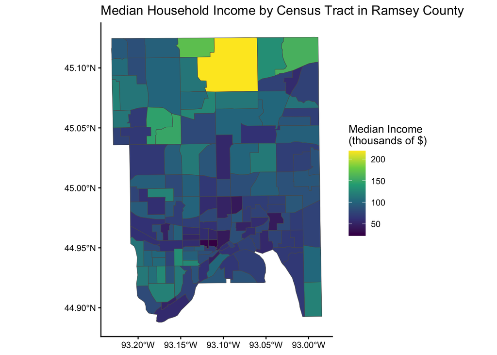

The map above displays the spatial distribution of typical household income. This pattern shows clear contrasts between the urban core and surrounding suburban areas, with higher income tracts forming clusters in the northern and western parts of the county. These geographic patterns motivate our interest in both economic conditions and spatial structure when studying differences in home values.

## Methods

To examine how median home values vary across census tracts in Ramsey County, we used regression models designed to account for potential spatial dependence. We first defined a neighborhood structure to formalize which tracts should be considered spatially close. Because Ramsey County contains both dense urban tracts and large suburban tracts, we used a k-nearest neighbors (KNN) structure with k = 3. This approach ensures that each tract has the same minimum number of neighbors and avoids the uneven or overly dense connectivity that can occur with contiguity-based definitions. The resulting spatial weights matrix was row-standardized so that each neighbor contributed equally.

Our baseline model used ordinary least squares (OLS) regression, with median home value (in thousands of dollars) as the outcome and median household income and median age as predictors. Spatial diagnostics were conducted using Moran’s I (Moran 1950), which tests whether neighboring residuals are more similar than expected under independence. The significant positive Moran’s I statistic indicated that the OLS residuals displayed spatial autocorrelation, violating a key model assumption and motivating the use of spatial models.

To address this issue, we fit two spatial error models: a Simultaneous Autoregressive (SAR) model and a Conditional Autoregressive (CAR) model, following the formulations in (Anselin 1981). Model selection was based on the Bayesian Information Criterion (BIC) and whether residual spatial autocorrelation persisted. The SAR model achieved the lowest BIC and produced residuals with no evidence of spatial dependence, and was therefore selected as our final model.

All analyses were conducted in R using the sf package for spatial data (Pebesma et al. 2018), the spdep package for spatial diagnostics (Bivand et al. 2017), and the spatialreg package for fitting spatial autoregressive models (Bivand and Piras 2015).

## Results

Our final model estimates an average increase of $1930 in home value for a thousandth unit increase in median household income. It also suggests that the older the population of the census tract, the higher home values tend to be on average. The p values produced by the model for both coefficients are very low, indicating that there isn’t enough evidence to say that these estimates were a result of randomness, making our coefficients statistically significant. The lambda value of our SAR model is 0.52, which suggests that there is spatial autocorrelation present in our data as it is far away from 0.

The Moran’s I estimate of the residuals is close to zero (-0.06), suggesting little to no strength in any underlying spatial correlation as the value is very close to zero. The P-value of this estimate is also much higher than 0.05, which gives us little evidence to reject the null hypothesis stating that there is spatial independence in the residuals. These suggest little to no noticeable spatial patterns in the residuals, which suggests independence in the data generation mechanism. This is a desired outcome, given that it agrees with the assumptions of independence made in our model estimation.

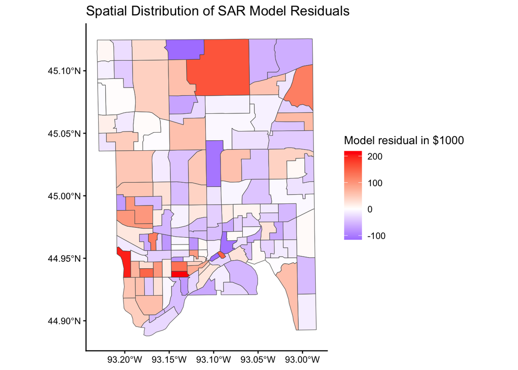

The residual map however shows little but noticeable spatial patterns, with some corners of the county showing clusters of high positive or negative residuals. Having thee KNN structured layered on the residual map shows how census tracts not connected tend to have different colors or no spatial correlation, and tracts highly connected tend to have similar color patterns as seen at the bottom center and bottom left of the map.

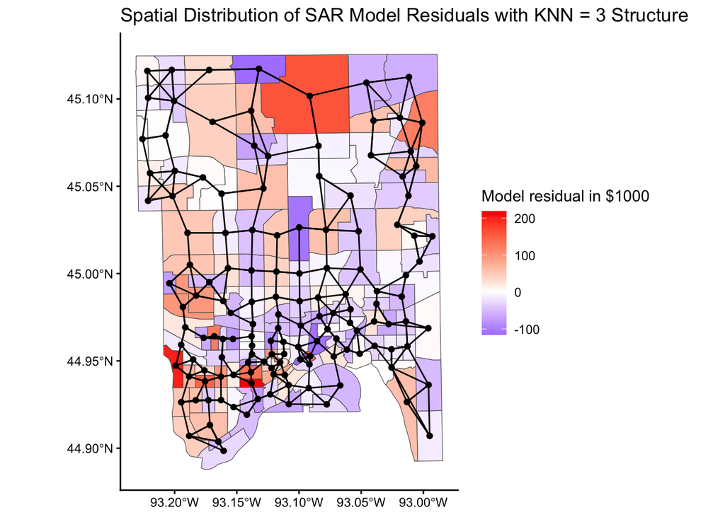

## Conclusions

Our analysis showed that areas where household income is higher tend to have higher home values on average, which is consistent with expectations about housing markets. Knowledge about areas of high or low income could then be beneficial for home searchers as to which areas to look into. We also found that tracts with older populations tend to have higher home values, which may reflect preferences for established neighborhoods or amenities that appeal to older residents such as the availability of senior homes and health establishments in proximity. The spatial error model effectively accounted for spatial dependence in the data, as indicated by the lack of residual autocorrelation, suggesting that we successfully captured most spatial patterns influencing home values, using the KNN neighborhood structure in our model. This goes to show that median income and median age help explain a good amount of the variations in home values across census tracts.

The residual map still showed some corners of the county with clusters of high positive or negative residuals, indicating that there may be other unmeasured factors influencing home values such as the home size or proximity to establishments like colleges, that were not included in our model. These patterns could also reflect limitations of the KNN neighborhood structure, which may not perfectly capture the true spatial relationships among tracts or allow relationships which may not actually be present. Future work could explore alternative neighborhood definitions or include additional covariates such as roads or lakes to better portray relationships among neighborhoods.

## Acknowledgements

We thank Brianna for her helpful feedback and suggestions throughout the project, and for obtaining and cleaning the spatial data used in this analysis.

## References

Anselin, Luc. 1981. “Estimation Methods for Spatial Autoregressive Structures.”

Bivand, Roger, Micah Altman, Luc Anselin, Renato Assunção, Olaf Berke, Andrew Bernat, and Guillaume Blanchet. 2017. “Package ‘Spdep’.” *Spatial Dependence: Weighting Schemes, Statistics, R Package Version* 1 (5).

Bivand, Roger, and Gianfranco Piras. 2015. “Comparing Implementations of Estimation Methods for Spatial Econometrics.” *Journal of Statistical Software* 63 (18): 1–36. https://doi.org/10.18637/jss.v063.i18.

Crowe, Timothy. 2022. “Effects of Redlining in the Twin Cities.”

Davis, Julie L. 2004. *American Indian Movement Survival Schools in Minneapolis and St. Paul, 1968–2002*. Arizona State University.

Faber, Jacob William. 2019. “Segregation and the Cost of Money: Race, Poverty, and the Prevalence of Alternative Financial Institutions.” *Social Forces* 98 (2): 819–48.

Jones, Alexis C. 2024. “From Covenants to Classrooms: Uncovering the Impact of Racial Segregation on Education in St. Paul, Minneapolis, and Duluth.”

Moran, Patrick AP. 1950. “Notes on Continuous Stochastic Phenomena.” *Biometrika* 37 (1/2): 17–23.

Pebesma, Edzer, Roger Bivand, Etienne Racine, Michael Sumner, Ian Cook, Tim Keitt, Robin Lovelace, et al. 2018. “Sf: Simple Features for r.” *R Package Version 0.6* 1.